# Before and After Black Rock City

## Increased Open-Mindedness and Comparing Settings

## Evaluation of Increased Open-Mindedness* After Going to Black Rock City

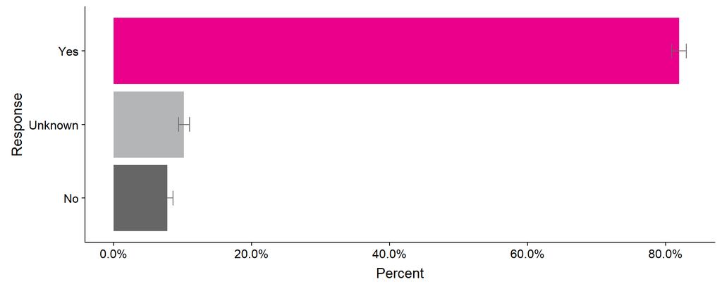

Error bars indicate the upper and lower bounds of the 95% confidence intervals.

* This question was first introduced in the 2018 online survey. The exact wording of this question in the online survey was, "Do you find yourself more open-minded and/or more willing to try new things after going to Black Rock City?"

|  | 2018 Percent | 2018 MoE +/- % |
| --- | --- | --- |
| Yes | 82.0 | 1.0 |
| Unknown | 10.2 | 0.8 |
| No | 7.8 | 0.6 |

## Comparing Settings

### Perceptions of Others

Participants were asked to use a scale to indicate the degree to which the statement below applied to them, from “Not at all like me” (1) to “Very much like me” (9) in Black Rock City and in the default world. The plot and table below represent responses for the statement:

*“When people smile at me, I assume they are demonstrating that they are friendly and approachable.”*

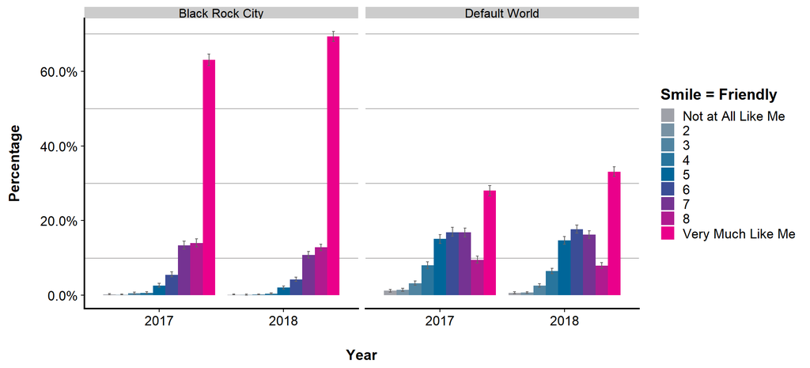

Error bars indicate the upper and lower bounds of the 95% confidence intervals.

|  | Black Rock City 2017 Percent | Black Rock City 2017 MoE +/- % | Black Rock City | Black Rock City 2018 Percent | 2018 MoE +/- % |  | Default World 2017 Percent | Default World 2017 MoE +/- % | Default World | Default World 2018 Percent | 2018 MoE +/- % |
| --- | --- | --- | --- | --- | --- | --- | --- | --- | --- | --- | --- |
| Not at All Like Me | 0.2 | 0.2 |  | 0.1 | 0.0 |  | 1.2 | 0.4 |  | 0.6 | 0.2 |
| 2 | 0.1 | 0.2 |  | 0.1 | 0.2 |  | 1.4 | 0.4 |  | 0.7 | 0.2 |
| 3 | 0.5 | 0.2 |  | 0.2 | 0.2 |  | 3.2 | 0.6 |  | 2.6 | 0.4 |
| 4 | 0.6 | 0.2 |  | 0.4 | 0.2 |  | 8.0 | 1.0 |  | 6.5 | 0.8 |
| 5 | 2.6 | 0.6 |  | 2.1 | 0.4 |  | 15.1 | 1.2 |  | 14.7 | 1.0 |
| 6 | 5.5 | 0.8 |  | 4.2 | 0.6 |  | 16.9 | 1.2 |  | 17.7 | 1.2 |
| 7 | 13.4 | 1.2 |  | 10.8 | 0.8 |  | 16.8 | 1.2 |  | 16.2 | 1.0 |
| 8 | 14.0 | 1.2 |  | 12.8 | 1.0 |  | 9.5 | 1.0 |  | 7.9 | 0.8 |
| Very Much Like Me | 63.1 | 1.6 |  | 69.3 | 1.4 |  | 28.0 | 1.4 |  | 33.1 | 1.4 |

## Comparing Settings

### Perceptions of Others

Participants were asked to use a scale to indicate the degree to which the statement below applied to them, from “Not at all like me” (1) to “Very much like me” (9) in Black Rock City and in the default world. The plot and table below represent responses for the statement:

*“When people smile at me, I assume they are feeling happy about something.”*

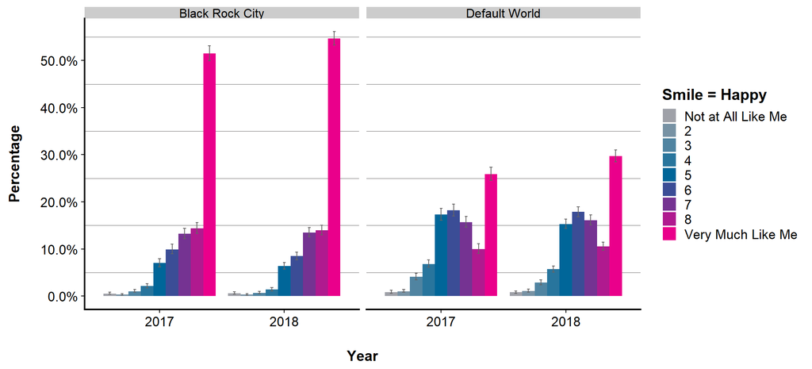

Error bars indicate the upper and lower bounds of the 95% confidence intervals.

|  | Black Rock City 2017 Percent | Black Rock City 2017 MoE +/- % | Black Rock City | Black Rock City 2018 Percent | 2018 MoE +/- % |  | Default World 2017 Percent | Default World 2017 MoE +/- % | Default World | Default World 2018 Percent | 2018 MoE +/- % |
| --- | --- | --- | --- | --- | --- | --- | --- | --- | --- | --- | --- |
| Not at All Like Me | 0.5 | 0.2 |  | 0.6 | 0.2 |  | 0.8 | 0.2 |  | 0.8 | 0.2 |
| 2 | 0.3 | 0.2 |  | 0.3 | 0.2 |  | 1.0 | 0.4 |  | 1.1 | 0.4 |
| 3 | 1.0 | 0.4 |  | 0.7 | 0.2 |  | 4.1 | 0.6 |  | 2.9 | 0.4 |
| 4 | 2.1 | 0.4 |  | 1.4 | 0.4 |  | 6.8 | 0.8 |  | 5.7 | 0.6 |
| 5 | 7.0 | 0.8 |  | 6.4 | 0.6 |  | 17.3 | 1.2 |  | 15.3 | 1.0 |
| 6 | 9.9 | 1.0 |  | 8.5 | 0.8 |  | 18.2 | 1.2 |  | 17.9 | 1.0 |
| 7 | 13.2 | 1.2 |  | 13.5 | 1.0 |  | 15.7 | 1.2 |  | 16.1 | 1.0 |
| 8 | 14.4 | 1.2 |  | 14.0 | 1.0 |  | 10.0 | 1.0 |  | 10.5 | 0.8 |
| Very Much Like Me | 51.5 | 1.6 |  | 54.7 | 1.4 |  | 25.9 | 1.4 |  | 29.7 | 1.2 |

## Comparing Settings

### Perceptions of Others

Participants were asked to use a scale to indicate the degree to which the statement below applied to them, from “Not at all like me” (1) to “Very much like me” (9) in Black Rock City and in the default world. The plot and table below represent responses for the statement:

*“When people smile at me, I assume they are trying to control me and put me in my place.”*

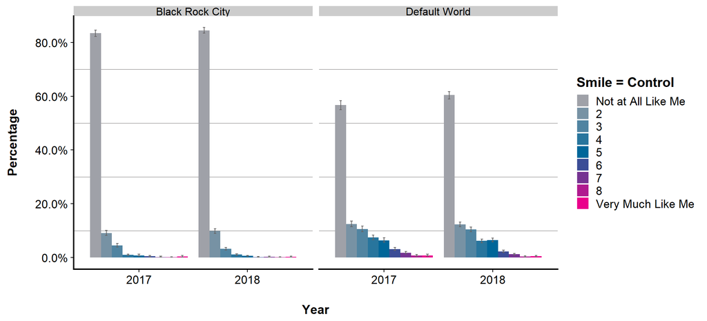

Error bars indicate the upper and lower bounds of the 95% confidence intervals.

|  | Black Rock City 2017 Percent | Black Rock City 2017 MoE +/- % | Black Rock City | Black Rock City 2018 Percent | 2018 MoE +/- % |  | Default World 2017 Percent | Default World 2017 MoE +/- % | Default World | Default World 2018 Percent | 2018 MoE +/- % |
| --- | --- | --- | --- | --- | --- | --- | --- | --- | --- | --- | --- |
| Not at All Like Me | 83.4 | 1.2 |  | 84.5 | 1.0 |  | 56.7 | 1.6 |  | 60.4 | 1.4 |
| 2 | 9.1 | 1.0 |  | 9.8 | 0.8 |  | 12.5 | 1.0 |  | 12.3 | 1.0 |
| 3 | 4.5 | 0.6 |  | 3.2 | 0.4 |  | 10.6 | 1.0 |  | 10.4 | 0.8 |
| 4 | 1.0 | 0.4 |  | 1.1 | 0.2 |  | 7.5 | 1.0 |  | 6.2 | 0.8 |
| 5 | 0.7 | 0.4 |  | 0.6 | 0.2 |  | 6.4 | 0.8 |  | 6.5 | 0.8 |
| 6 | 0.5 | 0.2 |  | 0.2 | 0.2 |  | 3.1 | 0.6 |  | 2.3 | 0.4 |
| 7 | 0.2 | 0.2 |  | 0.3 | 0.2 |  | 1.8 | 0.4 |  | 1.2 | 0.4 |
| 8 | 0.1 | 0.0 |  | 0.1 | 0.2 |  | 0.7 | 0.4 |  | 0.4 | 0.2 |
| Very Much Like Me | 0.4 | 0.2 |  | 0.3 | 0.2 |  | 0.8 | 0.4 |  | 0.5 | 0.2 |

## Comparing Settings

### Emotional Expression

Participants were asked to use a scale to indicate the degree to which the statement below applied to them, from “Not at all like me” (1) to “Very much like me” (9) in Black Rock City and in the default world. The plot and table below represent responses for the statement:

*“When I want to express an emotion, I can easily do so.”*

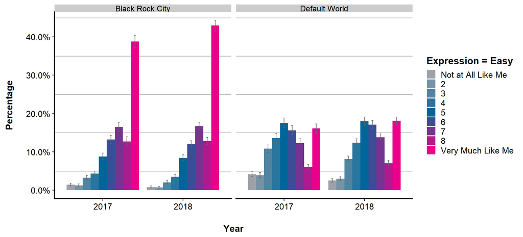

Error bars indicate the upper and lower bounds of the 95% confidence intervals.

|  | Black Rock City 2017 Percent | Black Rock City 2017 MoE +/- % | Black Rock City | Black Rock City 2018 Percent | 2018 MoE +/- % |  | Default World 2017 Percent | Default World 2017 MoE +/- % | Default World | Default World 2018 Percent | 2018 MoE +/- % |
| --- | --- | --- | --- | --- | --- | --- | --- | --- | --- | --- | --- |
| Not at All Like Me | 1.4 | 0.4 |  | 0.8 | 0.2 |  | 4.1 | 0.6 |  | 2.5 | 0.4 |
| 2 | 1.2 | 0.4 |  | 0.7 | 0.2 |  | 3.9 | 0.6 |  | 3.0 | 0.4 |
| 3 | 3.2 | 0.6 |  | 2.0 | 0.4 |  | 10.8 | 1.0 |  | 8.1 | 0.8 |
| 4 | 4.3 | 0.6 |  | 3.5 | 0.6 |  | 13.6 | 1.2 |  | 12.4 | 1.0 |
| 5 | 8.8 | 1.0 |  | 8.4 | 0.8 |  | 17.5 | 1.2 |  | 18.0 | 1.0 |
| 6 | 13.2 | 1.0 |  | 12.0 | 1.0 |  | 15.6 | 1.2 |  | 17.1 | 1.0 |
| 7 | 16.5 | 1.2 |  | 16.7 | 1.0 |  | 12.3 | 1.0 |  | 13.8 | 1.0 |
| 8 | 12.7 | 1.2 |  | 12.8 | 1.0 |  | 6.0 | 0.8 |  | 7.0 | 0.8 |
| Very Much Like Me | 38.8 | 1.6 |  | 43.0 | 1.4 |  | 16.1 | 1.2 |  | 18.1 | 1.0 |

## Comparing Settings

### Default World Status

Participants were asked to use a scale to indicate the degree to which the statement below applied to them, from “Not at all like me” (1) to “Very much like me” (9) in Black Rock City and in the default world. The plot and table below represent responses for the statement:

*“I feel that my status in the Default World (education, job, social standing) matters in my relations with people I meet.”*

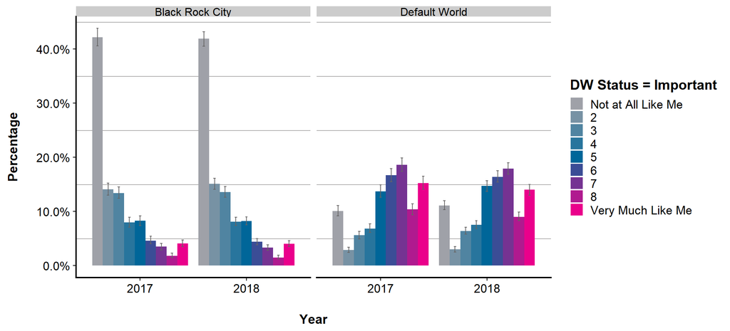

Error bars indicate the upper and lower bounds of the 95% confidence intervals.

|  | Black Rock City 2017 Percent | Black Rock City 2017 MoE +/- % | Black Rock City | Black Rock City 2018 Percent | 2018 MoE +/- % |  | Default World 2017 Percent | Default World 2017 MoE +/- % | Default World | Default World 2018 Percent | 2018 MoE +/- % |
| --- | --- | --- | --- | --- | --- | --- | --- | --- | --- | --- | --- |
| Not at All Like Me | 42.2 | 1.6 |  | 41.9 | 1.4 |  | 10.1 | 1.0 |  | 11.1 | 0.8 |
| 2 | 14.1 | 1.2 |  | 15.1 | 1.0 |  | 2.9 | 0.6 |  | 3.0 | 0.4 |
| 3 | 13.4 | 1.2 |  | 13.6 | 1.0 |  | 5.6 | 0.8 |  | 6.4 | 0.6 |
| 4 | 8.0 | 1.0 |  | 8.1 | 0.8 |  | 6.8 | 0.8 |  | 7.5 | 0.8 |
| 5 | 8.3 | 1.0 |  | 8.2 | 0.8 |  | 13.7 | 1.2 |  | 14.7 | 1.0 |
| 6 | 4.6 | 0.8 |  | 4.4 | 0.6 |  | 16.7 | 1.2 |  | 16.4 | 1.0 |
| 7 | 3.5 | 0.6 |  | 3.3 | 0.6 |  | 18.6 | 1.2 |  | 17.9 | 1.2 |
| 8 | 1.8 | 0.4 |  | 1.5 | 0.4 |  | 10.4 | 1.0 |  | 9.0 | 0.8 |
| Very Much Like Me | 4.1 | 0.6 |  | 4.0 | 0.6 |  | 15.2 | 1.2 |  | 14.0 | 1.0 |

**Next:** Before and After Black Rock City: Transformative Experience